# Risk Factor Analysis

## Outcome Variable

**Outcome Variable:** stunted

## Predictor Variables

**Intervention Variable:** exclfeed3

**Adjustment Set:**

- arm
- sex
- W_mage
- meducyrs
- feducyrs
- hhwealth_quart
- hfoodsec
- W_mhtcm
- vagbrth
- W_gagebrth
- W_birthwt
- W_birthlen
- W_nrooms
- W_nchldlt5
- month
- brthmon
- W_parity
- impfloor
- impsan
- safeh20
- delta_W_mage
- delta_meducyrs
- delta_feducyrs
- delta_hhwealth_quart
- delta_hfoodsec
- delta_W_mhtcm
- delta_vagbrth
- delta_W_gagebrth
- delta_W_birthwt
- delta_W_birthlen
- delta_W_nrooms
- delta_W_nchldlt5
- delta_month
- delta_brthmon
- delta_W_parity
- delta_impfloor
- delta_impsan
- delta_safeh20

## Stratifying Variables

The analysis was stratified on these variable(s):

- agecat
- studyid
- country

## Data Summary

| agecat | studyid | country | exclfeed3 | stunted | n_cell | n |
| --- | --- | --- | --- | --- | --- | --- |
| Birth | ki0047075b-MAL-ED | BANGLADESH | 0 | 0 | 55 | 240 |
| Birth | ki0047075b-MAL-ED | BANGLADESH | 0 | 1 | 12 | 240 |
| Birth | ki0047075b-MAL-ED | BANGLADESH | 1 | 0 | 144 | 240 |
| Birth | ki0047075b-MAL-ED | BANGLADESH | 1 | 1 | 29 | 240 |
| Birth | ki0047075b-MAL-ED | BRAZIL | 0 | 0 | 103 | 185 |
| Birth | ki0047075b-MAL-ED | BRAZIL | 0 | 1 | 15 | 185 |
| Birth | ki0047075b-MAL-ED | BRAZIL | 1 | 0 | 63 | 185 |
| Birth | ki0047075b-MAL-ED | BRAZIL | 1 | 1 | 4 | 185 |
| Birth | ki0047075b-MAL-ED | INDIA | 0 | 0 | 62 | 196 |
| Birth | ki0047075b-MAL-ED | INDIA | 0 | 1 | 11 | 196 |
| Birth | ki0047075b-MAL-ED | INDIA | 1 | 0 | 103 | 196 |
| Birth | ki0047075b-MAL-ED | INDIA | 1 | 1 | 20 | 196 |
| Birth | ki0047075b-MAL-ED | NEPAL | 0 | 0 | 95 | 171 |
| Birth | ki0047075b-MAL-ED | NEPAL | 0 | 1 | 15 | 171 |
| Birth | ki0047075b-MAL-ED | NEPAL | 1 | 0 | 58 | 171 |
| Birth | ki0047075b-MAL-ED | NEPAL | 1 | 1 | 3 | 171 |
| Birth | ki0047075b-MAL-ED | PERU | 0 | 0 | 186 | 272 |
| Birth | ki0047075b-MAL-ED | PERU | 0 | 1 | 19 | 272 |
| Birth | ki0047075b-MAL-ED | PERU | 1 | 0 | 54 | 272 |
| Birth | ki0047075b-MAL-ED | PERU | 1 | 1 | 13 | 272 |
| Birth | ki0047075b-MAL-ED | SOUTH AFRICA | 0 | 0 | 180 | 233 |
| Birth | ki0047075b-MAL-ED | SOUTH AFRICA | 0 | 1 | 21 | 233 |
| Birth | ki0047075b-MAL-ED | SOUTH AFRICA | 1 | 0 | 29 | 233 |
| Birth | ki0047075b-MAL-ED | SOUTH AFRICA | 1 | 1 | 3 | 233 |
| Birth | ki0047075b-MAL-ED | TANZANIA, UNITED REPUBLIC OF | 0 | 0 | 66 | 119 |
| Birth | ki0047075b-MAL-ED | TANZANIA, UNITED REPUBLIC OF | 0 | 1 | 14 | 119 |
| Birth | ki0047075b-MAL-ED | TANZANIA, UNITED REPUBLIC OF | 1 | 0 | 35 | 119 |
| Birth | ki0047075b-MAL-ED | TANZANIA, UNITED REPUBLIC OF | 1 | 1 | 4 | 119 |
| Birth | ki1000108-CMC-V-BCS-2002 | INDIA | 0 | 0 | 0 | 4 |
| Birth | ki1000108-CMC-V-BCS-2002 | INDIA | 0 | 1 | 0 | 4 |

[output cut: 146 more lines]

The following strata were considered:

- agecat: 24 months, studyid: ki0047075b-MAL-ED, country: BANGLADESH
- agecat: 24 months, studyid: ki0047075b-MAL-ED, country: BRAZIL
- agecat: 24 months, studyid: ki0047075b-MAL-ED, country: INDIA
- agecat: 24 months, studyid: ki0047075b-MAL-ED, country: NEPAL
- agecat: 24 months, studyid: ki0047075b-MAL-ED, country: PERU
- agecat: 24 months, studyid: ki0047075b-MAL-ED, country: SOUTH AFRICA
- agecat: 24 months, studyid: ki0047075b-MAL-ED, country: TANZANIA, UNITED REPUBLIC OF
- agecat: 24 months, studyid: ki1000108-CMC-V-BCS-2002, country: INDIA
- agecat: 24 months, studyid: ki1000108-IRC, country: INDIA
- agecat: 24 months, studyid: ki1017093b-PROVIDE, country: BANGLADESH
- agecat: 24 months, studyid: ki1101329-Keneba, country: GAMBIA
- agecat: 24 months, studyid: ki1113344-GMS-Nepal, country: NEPAL
- agecat: 24 months, studyid: kiGH5241-JiVitA-3, country: BANGLADESH
- agecat: 24 months, studyid: kiGH5241-JiVitA-4, country: BANGLADESH
- agecat: 6 months, studyid: ki0047075b-MAL-ED, country: BANGLADESH
- agecat: 6 months, studyid: ki0047075b-MAL-ED, country: BRAZIL
- agecat: 6 months, studyid: ki0047075b-MAL-ED, country: INDIA
- agecat: 6 months, studyid: ki0047075b-MAL-ED, country: NEPAL
- agecat: 6 months, studyid: ki0047075b-MAL-ED, country: PERU
- agecat: 6 months, studyid: ki0047075b-MAL-ED, country: SOUTH AFRICA
- agecat: 6 months, studyid: ki0047075b-MAL-ED, country: TANZANIA, UNITED REPUBLIC OF
- agecat: 6 months, studyid: ki1000108-CMC-V-BCS-2002, country: INDIA
- agecat: 6 months, studyid: ki1000108-IRC, country: INDIA
- agecat: 6 months, studyid: ki1000109-EE, country: PAKISTAN
- agecat: 6 months, studyid: ki1000304b-SAS-CompFeed, country: INDIA
- agecat: 6 months, studyid: ki1017093b-PROVIDE, country: BANGLADESH
- agecat: 6 months, studyid: ki1101329-Keneba, country: GAMBIA
- agecat: 6 months, studyid: ki1113344-GMS-Nepal, country: NEPAL
- agecat: 6 months, studyid: kiGH5241-JiVitA-3, country: BANGLADESH
- agecat: 6 months, studyid: kiGH5241-JiVitA-4, country: BANGLADESH
- agecat: Birth, studyid: ki0047075b-MAL-ED, country: BANGLADESH
- agecat: Birth, studyid: ki0047075b-MAL-ED, country: BRAZIL
- agecat: Birth, studyid: ki0047075b-MAL-ED, country: INDIA
- agecat: Birth, studyid: ki0047075b-MAL-ED, country: NEPAL
- agecat: Birth, studyid: ki0047075b-MAL-ED, country: PERU
- agecat: Birth, studyid: ki0047075b-MAL-ED, country: SOUTH AFRICA
- agecat: Birth, studyid: ki0047075b-MAL-ED, country: TANZANIA, UNITED REPUBLIC OF
- agecat: Birth, studyid: ki1000108-CMC-V-BCS-2002, country: INDIA
- agecat: Birth, studyid: ki1000108-IRC, country: INDIA
- agecat: Birth, studyid: ki1000109-EE, country: PAKISTAN
- agecat: Birth, studyid: ki1000304b-SAS-CompFeed, country: INDIA
- agecat: Birth, studyid: ki1101329-Keneba, country: GAMBIA
- agecat: Birth, studyid: kiGH5241-JiVitA-3, country: BANGLADESH
- agecat: Birth, studyid: kiGH5241-JiVitA-4, country: BANGLADESH

### Dropped Strata

Some strata were dropped due to rare outcomes:

- agecat: Birth, studyid: ki0047075b-MAL-ED, country: BRAZIL
- agecat: Birth, studyid: ki0047075b-MAL-ED, country: NEPAL
- agecat: Birth, studyid: ki0047075b-MAL-ED, country: SOUTH AFRICA
- agecat: Birth, studyid: ki0047075b-MAL-ED, country: TANZANIA, UNITED REPUBLIC OF
- agecat: Birth, studyid: ki1000108-CMC-V-BCS-2002, country: INDIA
- agecat: Birth, studyid: ki1000108-IRC, country: INDIA
- agecat: Birth, studyid: ki1000109-EE, country: PAKISTAN
- agecat: Birth, studyid: ki1000304b-SAS-CompFeed, country: INDIA
- agecat: Birth, studyid: kiGH5241-JiVitA-4, country: BANGLADESH
- agecat: 6 months, studyid: ki0047075b-MAL-ED, country: BRAZIL
- agecat: 6 months, studyid: ki0047075b-MAL-ED, country: SOUTH AFRICA
- agecat: 6 months, studyid: ki1000108-CMC-V-BCS-2002, country: INDIA
- agecat: 6 months, studyid: ki1000108-IRC, country: INDIA
- agecat: 24 months, studyid: ki0047075b-MAL-ED, country: BRAZIL
- agecat: 24 months, studyid: ki1000108-CMC-V-BCS-2002, country: INDIA
- agecat: 24 months, studyid: ki1000108-IRC, country: INDIA

## Methods Detail

We’re interested in the causal parameters $E[Y_a]$ for all values of $a \in \mathcal{A}$. These parameters represent the mean outcome if, possibly contrary to fact, we intervened to set all units to have $A=a$. Under the randomization and positivity assumptions, these are identified by the statistical parameters $\psi_a=E_W[E_{Y|A,W}(Y|A=a,W)]$. In addition, we’re interested in the mean of $Y$, $E[Y]$ under no intervention (the observed mean). We will estimate these parameters by using SuperLearner to fit the relevant likelihood factors – $E_{Y|A,W}(Y|A=a,W)$ and $p(A=a|W)$, and then updating our likelihood fit using a joint TMLE.

For unadjusted analyses ($W=\{\}$), initial likelihoods were estimated using Lrnr_glm to estimate the simple $E(Y|A)$ and Lrnr_mean to estimate $p(A)$. For adjusted analyses, a small library containing Lrnr_glmnet, Lrnr_xgboost, and Lrnr_mean was used.

Having estimated these parameters, we will then use the delta method to estimate relative risks and attributable risks relative to a prespecified baseline level of $A$.

# Results Detail

## Results Plots

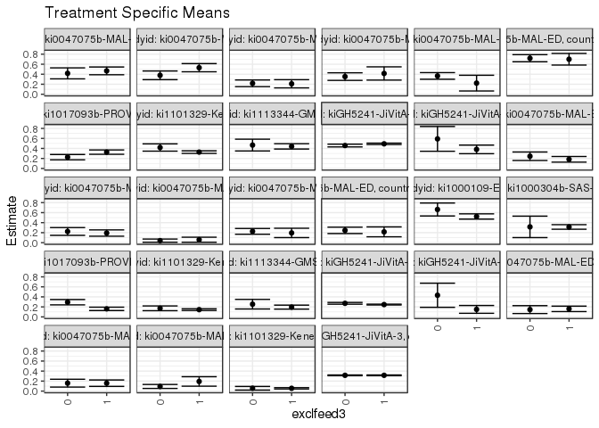

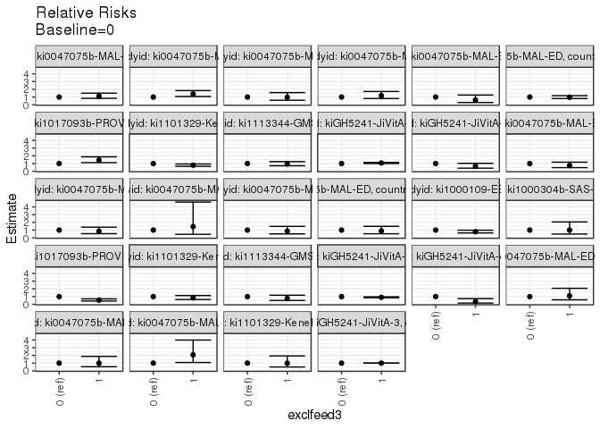

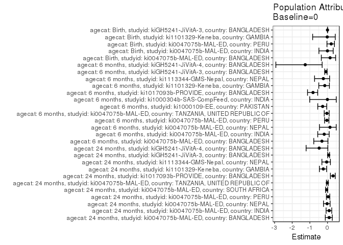

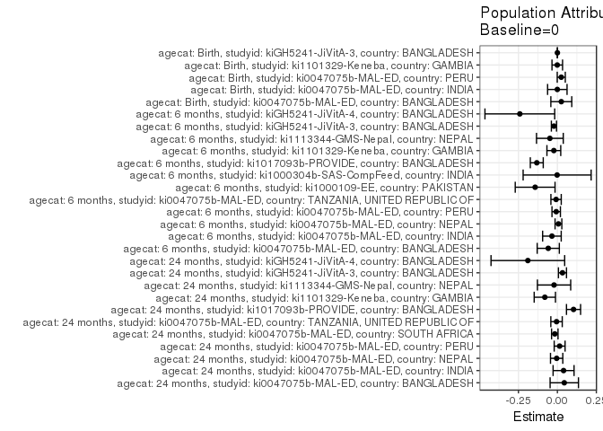

## Results Table

### Parameter: TSM

| agecat | studyid | country | intervention_level | baseline_level | estimate | ci_lower | ci_upper |
| --- | --- | --- | --- | --- | --- | --- | --- |
| Birth | ki0047075b-MAL-ED | BANGLADESH | 0 | NA | 0.1457785 | 0.0670883 | 0.2244687 |
| Birth | ki0047075b-MAL-ED | BANGLADESH | 1 | NA | 0.1604201 | 0.1061875 | 0.2146528 |
| Birth | ki0047075b-MAL-ED | INDIA | 0 | NA | 0.1586973 | 0.0804048 | 0.2369898 |
| Birth | ki0047075b-MAL-ED | INDIA | 1 | NA | 0.1583361 | 0.0942589 | 0.2224134 |
| Birth | ki0047075b-MAL-ED | PERU | 0 | NA | 0.0928880 | 0.0531528 | 0.1326233 |
| Birth | ki0047075b-MAL-ED | PERU | 1 | NA | 0.1928664 | 0.0980203 | 0.2877125 |
| Birth | ki1101329-Keneba | GAMBIA | 0 | NA | 0.0569620 | 0.0208096 | 0.0931144 |
| Birth | ki1101329-Keneba | GAMBIA | 1 | NA | 0.0560201 | 0.0429825 | 0.0690576 |
| Birth | kiGH5241-JiVitA-3 | BANGLADESH | 0 | NA | 0.3155926 | 0.3080231 | 0.3231622 |
| Birth | kiGH5241-JiVitA-3 | BANGLADESH | 1 | NA | 0.3156005 | 0.3080301 | 0.3231709 |
| 6 months | ki0047075b-MAL-ED | BANGLADESH | 0 | NA | 0.2443361 | 0.1598452 | 0.3288269 |
| 6 months | ki0047075b-MAL-ED | BANGLADESH | 1 | NA | 0.1827351 | 0.1265921 | 0.2388780 |
| 6 months | ki0047075b-MAL-ED | INDIA | 0 | NA | 0.2239956 | 0.1465725 | 0.3014186 |
| 6 months | ki0047075b-MAL-ED | INDIA | 1 | NA | 0.1919214 | 0.1289925 | 0.2548503 |
| 6 months | ki0047075b-MAL-ED | NEPAL | 0 | NA | 0.0405405 | 0.0086979 | 0.0723832 |
| 6 months | ki0047075b-MAL-ED | NEPAL | 1 | NA | 0.0588235 | 0.0086951 | 0.1089519 |
| 6 months | ki0047075b-MAL-ED | PERU | 0 | NA | 0.2262556 | 0.1686645 | 0.2838467 |
| 6 months | ki0047075b-MAL-ED | PERU | 1 | NA | 0.1949002 | 0.1016196 | 0.2881809 |
| 6 months | ki0047075b-MAL-ED | TANZANIA, UNITED REPUBLIC OF | 0 | NA | 0.2459961 | 0.1822474 | 0.3097448 |
| 6 months | ki0047075b-MAL-ED | TANZANIA, UNITED REPUBLIC OF | 1 | NA | 0.2161308 | 0.1172615 | 0.3150000 |
| 6 months | ki1000109-EE | PAKISTAN | 0 | NA | 0.6631028 | 0.5336678 | 0.7925377 |
| 6 months | ki1000109-EE | PAKISTAN | 1 | NA | 0.5230512 | 0.4705916 | 0.5755108 |
| 6 months | ki1000304b-SAS-CompFeed | INDIA | 0 | NA | 0.3157895 | 0.1014523 | 0.5301266 |
| 6 months | ki1000304b-SAS-CompFeed | INDIA | 1 | NA | 0.3139842 | 0.2679102 | 0.3600581 |
| 6 months | ki1017093b-PROVIDE | BANGLADESH | 0 | NA | 0.2935337 | 0.2403279 | 0.3467396 |
| 6 months | ki1017093b-PROVIDE | BANGLADESH | 1 | NA | 0.1603824 | 0.1269034 | 0.1938614 |
| 6 months | ki1101329-Keneba | GAMBIA | 0 | NA | 0.1715731 | 0.1239166 | 0.2192295 |
| 6 months | ki1101329-Keneba | GAMBIA | 1 | NA | 0.1446998 | 0.1271649 | 0.1622346 |
| 6 months | ki1113344-GMS-Nepal | NEPAL | 0 | NA | 0.2535332 | 0.1576771 | 0.3493893 |
| 6 months | ki1113344-GMS-Nepal | NEPAL | 1 | NA | 0.1951870 | 0.1552525 | 0.2351215 |
| 6 months | kiGH5241-JiVitA-3 | BANGLADESH | 0 | NA | 0.2710966 | 0.2531141 | 0.2890792 |
| 6 months | kiGH5241-JiVitA-3 | BANGLADESH | 1 | NA | 0.2461051 | 0.2376964 | 0.2545139 |
| 6 months | kiGH5241-JiVitA-4 | BANGLADESH | 0 | NA | 0.4321132 | 0.1908889 | 0.6733375 |
| 6 months | kiGH5241-JiVitA-4 | BANGLADESH | 1 | NA | 0.1496157 | 0.0714682 | 0.2277633 |
| 24 months | ki0047075b-MAL-ED | BANGLADESH | 0 | NA | 0.4173584 | 0.3077395 | 0.5269773 |
| 24 months | ki0047075b-MAL-ED | BANGLADESH | 1 | NA | 0.4669672 | 0.3893597 | 0.5445747 |
| 24 months | ki0047075b-MAL-ED | INDIA | 0 | NA | 0.3781751 | 0.2913950 | 0.4649551 |
| 24 months | ki0047075b-MAL-ED | INDIA | 1 | NA | 0.5306021 | 0.4489196 | 0.6122846 |
| 24 months | ki0047075b-MAL-ED | NEPAL | 0 | NA | 0.2181501 | 0.1516511 | 0.2846491 |
| 24 months | ki0047075b-MAL-ED | NEPAL | 1 | NA | 0.2089836 | 0.1269067 | 0.2910605 |
| 24 months | ki0047075b-MAL-ED | PERU | 0 | NA | 0.3525082 | 0.2766893 | 0.4283272 |
| 24 months | ki0047075b-MAL-ED | PERU | 1 | NA | 0.4149985 | 0.2825635 | 0.5474334 |
| 24 months | ki0047075b-MAL-ED | SOUTH AFRICA | 0 | NA | 0.3658537 | 0.2997755 | 0.4319318 |
| 24 months | ki0047075b-MAL-ED | SOUTH AFRICA | 1 | NA | 0.2222222 | 0.0650681 | 0.3793763 |
| 24 months | ki0047075b-MAL-ED | TANZANIA, UNITED REPUBLIC OF | 0 | NA | 0.7198314 | 0.6489582 | 0.7907046 |
| 24 months | ki0047075b-MAL-ED | TANZANIA, UNITED REPUBLIC OF | 1 | NA | 0.6994057 | 0.5830180 | 0.8157935 |
| 24 months | ki1017093b-PROVIDE | BANGLADESH | 0 | NA | 0.2257737 | 0.1725377 | 0.2790097 |
| 24 months | ki1017093b-PROVIDE | BANGLADESH | 1 | NA | 0.3267808 | 0.2833156 | 0.3702460 |
| 24 months | ki1101329-Keneba | GAMBIA | 0 | NA | 0.4187197 | 0.3457409 | 0.4916985 |
| 24 months | ki1101329-Keneba | GAMBIA | 1 | NA | 0.3269201 | 0.3013203 | 0.3525200 |
| 24 months | ki1113344-GMS-Nepal | NEPAL | 0 | NA | 0.4670453 | 0.3496901 | 0.5844004 |
| 24 months | ki1113344-GMS-Nepal | NEPAL | 1 | NA | 0.4411903 | 0.3881167 | 0.4942640 |
| 24 months | kiGH5241-JiVitA-3 | BANGLADESH | 0 | NA | 0.4579454 | 0.4302092 | 0.4856817 |
| 24 months | kiGH5241-JiVitA-3 | BANGLADESH | 1 | NA | 0.4921877 | 0.4783096 | 0.5060658 |
| 24 months | kiGH5241-JiVitA-4 | BANGLADESH | 0 | NA | 0.5909576 | 0.3435117 | 0.8384035 |
| 24 months | kiGH5241-JiVitA-4 | BANGLADESH | 1 | NA | 0.3808735 | 0.2950078 | 0.4667392 |

### Parameter: E(Y)

| agecat | studyid | country | intervention_level | baseline_level | estimate | ci_lower | ci_upper |
| --- | --- | --- | --- | --- | --- | --- | --- |
| Birth | ki0047075b-MAL-ED | BANGLADESH | NA | NA | 0.1708333 | 0.1231182 | 0.2185485 |
| Birth | ki0047075b-MAL-ED | INDIA | NA | NA | 0.1581633 | 0.1069482 | 0.2093783 |
| Birth | ki0047075b-MAL-ED | PERU | NA | NA | 0.1176471 | 0.0792874 | 0.1560068 |
| Birth | ki1101329-Keneba | GAMBIA | NA | NA | 0.0561300 | 0.0438654 | 0.0683946 |
| Birth | kiGH5241-JiVitA-3 | BANGLADESH | NA | NA | 0.3156066 | 0.3080361 | 0.3231771 |
| 6 months | ki0047075b-MAL-ED | BANGLADESH | NA | NA | 0.1856540 | 0.1360464 | 0.2352617 |
| 6 months | ki0047075b-MAL-ED | INDIA | NA | NA | 0.1888412 | 0.1384789 | 0.2392035 |
| 6 months | ki0047075b-MAL-ED | NEPAL | NA | NA | 0.0472103 | 0.0199192 | 0.0745014 |
| 6 months | ki0047075b-MAL-ED | PERU | NA | NA | 0.2185185 | 0.1691358 | 0.2679013 |
| 6 months | ki0047075b-MAL-ED | TANZANIA, UNITED REPUBLIC OF | NA | NA | 0.2375000 | 0.1835488 | 0.2914512 |
| 6 months | ki1000109-EE | PAKISTAN | NA | NA | 0.5202156 | 0.4693105 | 0.5711208 |
| 6 months | ki1000304b-SAS-CompFeed | INDIA | NA | NA | 0.3140704 | 0.2712850 | 0.3568557 |
| 6 months | ki1017093b-PROVIDE | BANGLADESH | NA | NA | 0.1612350 | 0.1313580 | 0.1911120 |
| 6 months | ki1101329-Keneba | GAMBIA | NA | NA | 0.1486797 | 0.1319680 | 0.1653914 |
| 6 months | ki1113344-GMS-Nepal | NEPAL | NA | NA | 0.2052402 | 0.1682114 | 0.2422689 |
| 6 months | kiGH5241-JiVitA-3 | BANGLADESH | NA | NA | 0.2489405 | 0.2407278 | 0.2571531 |
| 6 months | kiGH5241-JiVitA-4 | BANGLADESH | NA | NA | 0.1910112 | 0.1139350 | 0.2680874 |
| 24 months | ki0047075b-MAL-ED | BANGLADESH | NA | NA | 0.4615385 | 0.3936268 | 0.5294501 |
| 24 months | ki0047075b-MAL-ED | INDIA | NA | NA | 0.4177778 | 0.3531914 | 0.4823642 |
| 24 months | ki0047075b-MAL-ED | NEPAL | NA | NA | 0.2133333 | 0.1596859 | 0.2669808 |
| 24 months | ki0047075b-MAL-ED | PERU | NA | NA | 0.3668342 | 0.2997053 | 0.4339630 |
| 24 months | ki0047075b-MAL-ED | SOUTH AFRICA | NA | NA | 0.3491379 | 0.2876648 | 0.4106110 |
| 24 months | ki0047075b-MAL-ED | TANZANIA, UNITED REPUBLIC OF | NA | NA | 0.7142857 | 0.6530398 | 0.7755316 |
| 24 months | ki1017093b-PROVIDE | BANGLADESH | NA | NA | 0.3292894 | 0.2909105 | 0.3676684 |
| 24 months | ki1101329-Keneba | GAMBIA | NA | NA | 0.3380282 | 0.3134158 | 0.3626405 |
| 24 months | ki1113344-GMS-Nepal | NEPAL | NA | NA | 0.4455446 | 0.3970186 | 0.4940706 |
| 24 months | kiGH5241-JiVitA-3 | BANGLADESH | NA | NA | 0.4904688 | 0.4770397 | 0.5038978 |
| 24 months | kiGH5241-JiVitA-4 | BANGLADESH | NA | NA | 0.4013158 | 0.3195309 | 0.4831007 |

### Parameter: RR

| agecat | studyid | country | intervention_level | baseline_level | estimate | ci_lower | ci_upper |
| --- | --- | --- | --- | --- | --- | --- | --- |
| Birth | ki0047075b-MAL-ED | BANGLADESH | 0 | 0 | 1.0000000 | 1.0000000 | 1.0000000 |
| Birth | ki0047075b-MAL-ED | BANGLADESH | 1 | 0 | 1.1004378 | 0.5831271 | 2.0766711 |
| Birth | ki0047075b-MAL-ED | INDIA | 0 | 0 | 1.0000000 | 1.0000000 | 1.0000000 |
| Birth | ki0047075b-MAL-ED | INDIA | 1 | 0 | 0.9977242 | 0.5321166 | 1.8707434 |
| Birth | ki0047075b-MAL-ED | PERU | 0 | 0 | 1.0000000 | 1.0000000 | 1.0000000 |
| Birth | ki0047075b-MAL-ED | PERU | 1 | 0 | 2.0763328 | 1.0827230 | 3.9817735 |
| Birth | ki1101329-Keneba | GAMBIA | 0 | 0 | 1.0000000 | 1.0000000 | 1.0000000 |
| Birth | ki1101329-Keneba | GAMBIA | 1 | 0 | 0.9834634 | 0.5002360 | 1.9334878 |
| Birth | kiGH5241-JiVitA-3 | BANGLADESH | 0 | 0 | 1.0000000 | 1.0000000 | 1.0000000 |
| Birth | kiGH5241-JiVitA-3 | BANGLADESH | 1 | 0 | 1.0000249 | 0.9999822 | 1.0000676 |
| 6 months | ki0047075b-MAL-ED | BANGLADESH | 0 | 0 | 1.0000000 | 1.0000000 | 1.0000000 |
| 6 months | ki0047075b-MAL-ED | BANGLADESH | 1 | 0 | 0.7478842 | 0.4741625 | 1.1796183 |
| 6 months | ki0047075b-MAL-ED | INDIA | 0 | 0 | 1.0000000 | 1.0000000 | 1.0000000 |
| 6 months | ki0047075b-MAL-ED | INDIA | 1 | 0 | 0.8568088 | 0.5335209 | 1.3759937 |
| 6 months | ki0047075b-MAL-ED | NEPAL | 0 | 0 | 1.0000000 | 1.0000000 | 1.0000000 |
| 6 months | ki0047075b-MAL-ED | NEPAL | 1 | 0 | 1.4509804 | 0.4553431 | 4.6236432 |
| 6 months | ki0047075b-MAL-ED | PERU | 0 | 0 | 1.0000000 | 1.0000000 | 1.0000000 |
| 6 months | ki0047075b-MAL-ED | PERU | 1 | 0 | 0.8614162 | 0.5024297 | 1.4768991 |
| 6 months | ki0047075b-MAL-ED | TANZANIA, UNITED REPUBLIC OF | 0 | 0 | 1.0000000 | 1.0000000 | 1.0000000 |
| 6 months | ki0047075b-MAL-ED | TANZANIA, UNITED REPUBLIC OF | 1 | 0 | 0.8785945 | 0.5209331 | 1.4818185 |
| 6 months | ki1000109-EE | PAKISTAN | 0 | 0 | 1.0000000 | 1.0000000 | 1.0000000 |
| 6 months | ki1000109-EE | PAKISTAN | 1 | 0 | 0.7887935 | 0.6334192 | 0.9822803 |
| 6 months | ki1000304b-SAS-CompFeed | INDIA | 0 | 0 | 1.0000000 | 1.0000000 | 1.0000000 |
| 6 months | ki1000304b-SAS-CompFeed | INDIA | 1 | 0 | 0.9942832 | 0.4810773 | 2.0549693 |
| 6 months | ki1017093b-PROVIDE | BANGLADESH | 0 | 0 | 1.0000000 | 1.0000000 | 1.0000000 |
| 6 months | ki1017093b-PROVIDE | BANGLADESH | 1 | 0 | 0.5463850 | 0.4228143 | 0.7060702 |
| 6 months | ki1101329-Keneba | GAMBIA | 0 | 0 | 1.0000000 | 1.0000000 | 1.0000000 |
| 6 months | ki1101329-Keneba | GAMBIA | 1 | 0 | 0.8433711 | 0.6244879 | 1.1389730 |
| 6 months | ki1113344-GMS-Nepal | NEPAL | 0 | 0 | 1.0000000 | 1.0000000 | 1.0000000 |
| 6 months | ki1113344-GMS-Nepal | NEPAL | 1 | 0 | 0.7698677 | 0.5010049 | 1.1830148 |
| 6 months | kiGH5241-JiVitA-3 | BANGLADESH | 0 | 0 | 1.0000000 | 1.0000000 | 1.0000000 |
| 6 months | kiGH5241-JiVitA-3 | BANGLADESH | 1 | 0 | 0.9078133 | 0.8474397 | 0.9724881 |
| 6 months | kiGH5241-JiVitA-4 | BANGLADESH | 0 | 0 | 1.0000000 | 1.0000000 | 1.0000000 |
| 6 months | kiGH5241-JiVitA-4 | BANGLADESH | 1 | 0 | 0.3462420 | 0.1624801 | 0.7378349 |
| 24 months | ki0047075b-MAL-ED | BANGLADESH | 0 | 0 | 1.0000000 | 1.0000000 | 1.0000000 |
| 24 months | ki0047075b-MAL-ED | BANGLADESH | 1 | 0 | 1.1188638 | 0.8327662 | 1.5032505 |
| 24 months | ki0047075b-MAL-ED | INDIA | 0 | 0 | 1.0000000 | 1.0000000 | 1.0000000 |
| 24 months | ki0047075b-MAL-ED | INDIA | 1 | 0 | 1.4030595 | 1.0741190 | 1.8327353 |
| 24 months | ki0047075b-MAL-ED | NEPAL | 0 | 0 | 1.0000000 | 1.0000000 | 1.0000000 |
| 24 months | ki0047075b-MAL-ED | NEPAL | 1 | 0 | 0.9579809 | 0.5825123 | 1.5754643 |
| 24 months | ki0047075b-MAL-ED | PERU | 0 | 0 | 1.0000000 | 1.0000000 | 1.0000000 |
| 24 months | ki0047075b-MAL-ED | PERU | 1 | 0 | 1.1772731 | 0.8073106 | 1.7167766 |
| 24 months | ki0047075b-MAL-ED | SOUTH AFRICA | 0 | 0 | 1.0000000 | 1.0000000 | 1.0000000 |
| 24 months | ki0047075b-MAL-ED | SOUTH AFRICA | 1 | 0 | 0.6074074 | 0.2927464 | 1.2602845 |
| 24 months | ki0047075b-MAL-ED | TANZANIA, UNITED REPUBLIC OF | 0 | 0 | 1.0000000 | 1.0000000 | 1.0000000 |
| 24 months | ki0047075b-MAL-ED | TANZANIA, UNITED REPUBLIC OF | 1 | 0 | 0.9716244 | 0.8025814 | 1.1762719 |
| 24 months | ki1017093b-PROVIDE | BANGLADESH | 0 | 0 | 1.0000000 | 1.0000000 | 1.0000000 |
| 24 months | ki1017093b-PROVIDE | BANGLADESH | 1 | 0 | 1.4473820 | 1.1186427 | 1.8727291 |
| 24 months | ki1101329-Keneba | GAMBIA | 0 | 0 | 1.0000000 | 1.0000000 | 1.0000000 |
| 24 months | ki1101329-Keneba | GAMBIA | 1 | 0 | 0.7807613 | 0.6467393 | 0.9425563 |
| 24 months | ki1113344-GMS-Nepal | NEPAL | 0 | 0 | 1.0000000 | 1.0000000 | 1.0000000 |
| 24 months | ki1113344-GMS-Nepal | NEPAL | 1 | 0 | 0.9446415 | 0.7156267 | 1.2469456 |
| 24 months | kiGH5241-JiVitA-3 | BANGLADESH | 0 | 0 | 1.0000000 | 1.0000000 | 1.0000000 |
| 24 months | kiGH5241-JiVitA-3 | BANGLADESH | 1 | 0 | 1.0747737 | 1.0091612 | 1.1446520 |
| 24 months | kiGH5241-JiVitA-4 | BANGLADESH | 0 | 0 | 1.0000000 | 1.0000000 | 1.0000000 |
| 24 months | kiGH5241-JiVitA-4 | BANGLADESH | 1 | 0 | 0.6445022 | 0.4031347 | 1.0303828 |

### Parameter: PAR

| agecat | studyid | country | intervention_level | baseline_level | estimate | ci_lower | ci_upper |
| --- | --- | --- | --- | --- | --- | --- | --- |
| Birth | ki0047075b-MAL-ED | BANGLADESH | 0 | NA | 0.0250549 | -0.0420170 | 0.0921267 |
| Birth | ki0047075b-MAL-ED | INDIA | 0 | NA | -0.0005340 | -0.0629595 | 0.0618915 |
| Birth | ki0047075b-MAL-ED | PERU | 0 | NA | 0.0247590 | -0.0010744 | 0.0505925 |
| Birth | ki1101329-Keneba | GAMBIA | 0 | NA | -0.0008320 | -0.0347789 | 0.0331148 |
| Birth | kiGH5241-JiVitA-3 | BANGLADESH | 0 | NA | 0.0000140 | 0.0000021 | 0.0000259 |
| 6 months | ki0047075b-MAL-ED | BANGLADESH | 0 | NA | -0.0586821 | -0.1297339 | 0.0123698 |
| 6 months | ki0047075b-MAL-ED | INDIA | 0 | NA | -0.0351544 | -0.0947745 | 0.0244658 |
| 6 months | ki0047075b-MAL-ED | NEPAL | 0 | NA | 0.0066698 | -0.0150246 | 0.0283641 |
| 6 months | ki0047075b-MAL-ED | PERU | 0 | NA | -0.0077371 | -0.0348046 | 0.0193304 |
| 6 months | ki0047075b-MAL-ED | TANZANIA, UNITED REPUBLIC OF | 0 | NA | -0.0084961 | -0.0416494 | 0.0246572 |
| 6 months | ki1000109-EE | PAKISTAN | 0 | NA | -0.1428872 | -0.2705829 | -0.0151914 |
| 6 months | ki1000304b-SAS-CompFeed | INDIA | 0 | NA | -0.0017191 | -0.2199177 | 0.2164795 |
| 6 months | ki1017093b-PROVIDE | BANGLADESH | 0 | NA | -0.1322987 | -0.1737793 | -0.0908181 |
| 6 months | ki1101329-Keneba | GAMBIA | 0 | NA | -0.0228934 | -0.0672021 | 0.0214153 |
| 6 months | ki1113344-GMS-Nepal | NEPAL | 0 | NA | -0.0482930 | -0.1341951 | 0.0376090 |
| 6 months | kiGH5241-JiVitA-3 | BANGLADESH | 0 | NA | -0.0221562 | -0.0386875 | -0.0056248 |
| 6 months | kiGH5241-JiVitA-4 | BANGLADESH | 0 | NA | -0.2411020 | -0.4648855 | -0.0173185 |
| 24 months | ki0047075b-MAL-ED | BANGLADESH | 0 | NA | 0.0441800 | -0.0468125 | 0.1351726 |
| 24 months | ki0047075b-MAL-ED | INDIA | 0 | NA | 0.0396027 | -0.0276567 | 0.1068621 |
| 24 months | ki0047075b-MAL-ED | NEPAL | 0 | NA | -0.0048168 | -0.0442516 | 0.0346181 |
| 24 months | ki0047075b-MAL-ED | PERU | 0 | NA | 0.0143259 | -0.0205604 | 0.0492123 |
| 24 months | ki0047075b-MAL-ED | SOUTH AFRICA | 0 | NA | -0.0167157 | -0.0374262 | 0.0039947 |
| 24 months | ki0047075b-MAL-ED | TANZANIA, UNITED REPUBLIC OF | 0 | NA | -0.0055457 | -0.0421435 | 0.0310522 |
| 24 months | ki1017093b-PROVIDE | BANGLADESH | 0 | NA | 0.1035157 | 0.0583007 | 0.1487308 |
| 24 months | ki1101329-Keneba | GAMBIA | 0 | NA | -0.0806915 | -0.1489898 | -0.0123932 |
| 24 months | ki1113344-GMS-Nepal | NEPAL | 0 | NA | -0.0215007 | -0.1282763 | 0.0852749 |
| 24 months | kiGH5241-JiVitA-3 | BANGLADESH | 0 | NA | 0.0325233 | 0.0066717 | 0.0583749 |
| 24 months | kiGH5241-JiVitA-4 | BANGLADESH | 0 | NA | -0.1896418 | -0.4259350 | 0.0466515 |

### Parameter: PAF

| agecat | studyid | country | intervention_level | baseline_level | estimate | ci_lower | ci_upper |
| --- | --- | --- | --- | --- | --- | --- | --- |
| Birth | ki0047075b-MAL-ED | BANGLADESH | 0 | NA | 0.1466626 | -0.3493468 | 0.4603428 |
| Birth | ki0047075b-MAL-ED | INDIA | 0 | NA | -0.0033764 | -0.4870599 | 0.3229835 |
| Birth | ki0047075b-MAL-ED | PERU | 0 | NA | 0.2104519 | -0.0310929 | 0.3954122 |
| Birth | ki1101329-Keneba | GAMBIA | 0 | NA | -0.0148235 | -0.8416510 | 0.4407916 |
| Birth | kiGH5241-JiVitA-3 | BANGLADESH | 0 | NA | 0.0000443 | 0.0000066 | 0.0000820 |
| 6 months | ki0047075b-MAL-ED | BANGLADESH | 0 | NA | -0.3160829 | -0.7784262 | 0.0260634 |
| 6 months | ki0047075b-MAL-ED | INDIA | 0 | NA | -0.1861583 | -0.5539831 | 0.0946030 |
| 6 months | ki0047075b-MAL-ED | NEPAL | 0 | NA | 0.1412776 | -0.4550333 | 0.4932047 |
| 6 months | ki0047075b-MAL-ED | PERU | 0 | NA | -0.0354070 | -0.1667895 | 0.0811816 |
| 6 months | ki0047075b-MAL-ED | TANZANIA, UNITED REPUBLIC OF | 0 | NA | -0.0357729 | -0.1853398 | 0.0949215 |
| 6 months | ki1000109-EE | PAKISTAN | 0 | NA | -0.2746691 | -0.5524546 | -0.0465886 |
| 6 months | ki1000304b-SAS-CompFeed | INDIA | 0 | NA | -0.0054737 | -1.0068383 | 0.4962338 |
| 6 months | ki1017093b-PROVIDE | BANGLADESH | 0 | NA | -0.8205335 | -1.1315315 | -0.5549113 |
| 6 months | ki1101329-Keneba | GAMBIA | 0 | NA | -0.1539779 | -0.4942296 | 0.1087949 |
| 6 months | ki1113344-GMS-Nepal | NEPAL | 0 | NA | -0.2353001 | -0.7324028 | 0.1191619 |
| 6 months | kiGH5241-JiVitA-3 | BANGLADESH | 0 | NA | -0.0890018 | -0.1577431 | -0.0243421 |
| 6 months | kiGH5241-JiVitA-4 | BANGLADESH | 0 | NA | -1.2622399 | -2.9271867 | -0.3031541 |
| 24 months | ki0047075b-MAL-ED | BANGLADESH | 0 | NA | 0.0957234 | -0.1239538 | 0.2724646 |
| 24 months | ki0047075b-MAL-ED | INDIA | 0 | NA | 0.0947937 | -0.0798490 | 0.2411917 |
| 24 months | ki0047075b-MAL-ED | NEPAL | 0 | NA | -0.0225786 | -0.2253132 | 0.1466125 |
| 24 months | ki0047075b-MAL-ED | PERU | 0 | NA | 0.0390529 | -0.0612517 | 0.1298771 |
| 24 months | ki0047075b-MAL-ED | SOUTH AFRICA | 0 | NA | -0.0478771 | -0.1089858 | 0.0098642 |
| 24 months | ki0047075b-MAL-ED | TANZANIA, UNITED REPUBLIC OF | 0 | NA | -0.0077640 | -0.0603409 | 0.0422059 |
| 24 months | ki1017093b-PROVIDE | BANGLADESH | 0 | NA | 0.3143609 | 0.1651950 | 0.4368733 |
| 24 months | ki1101329-Keneba | GAMBIA | 0 | NA | -0.2387125 | -0.4587156 | -0.0518902 |
| 24 months | ki1113344-GMS-Nepal | NEPAL | 0 | NA | -0.0482572 | -0.3175782 | 0.1660130 |
| 24 months | kiGH5241-JiVitA-3 | BANGLADESH | 0 | NA | 0.0663107 | 0.0122734 | 0.1173917 |
| 24 months | kiGH5241-JiVitA-4 | BANGLADESH | 0 | NA | -0.4725500 | -1.2129163 | 0.0201150 |